# ExtraaLearn Project

### Observation

- There are 174 records in the dataset where the "website_visits" column is equal to 0.
- The number of columns has increased from 14 to 16 after the data manipulation

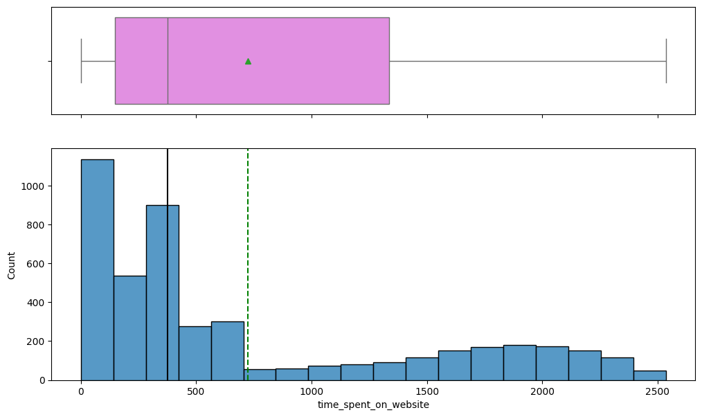

```python
plot(X, "time_spent_on_website") #plots for time_spent_on_website using 'plot' function after manipulation
```

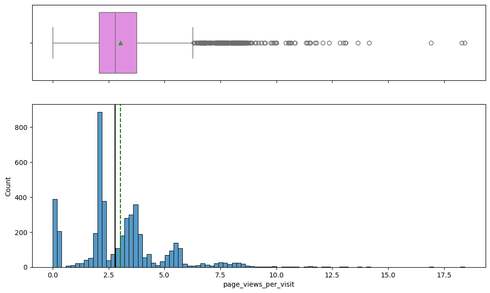

```python
plot(X, "page_views_per_visit") #plots for page_views_per_visit using 'plot' function (post manipulation)
```

```python
# Function to print Classification Report and Confusion matrix

def report(actual, predicted):
    print(classification_report(actual, predicted))
    confMatrix = confusion_matrix(actual, predicted)

    plt.figure(figsize = (8, 5))
    sns.heatmap(confMatrix, annot = True, fmt = '.2f', xticklabels = ['Not Converted', 'Converted'], yticklabels = ['Not Converted', 'Converted'])
    plt.ylabel('Actual')
    plt.xlabel('Predicted')
    plt.show()
```

## Building a Decision Tree model

```python
# Fit the decision tree model on the training data
dtree = DecisionTreeClassifier(random_state=1)
dtree.fit(X_train, y_train)
```

```
DecisionTreeClassifier(random_state=1)
```

```
Decision Tree - Training Set Performance:
              precision    recall  f1-score   support

           0       1.00      1.00      1.00      2273
           1       1.00      1.00      1.00       955

    accuracy                           1.00      3228
   macro avg       1.00      1.00      1.00      3228
weighted avg       1.00      1.00      1.00      3228
```

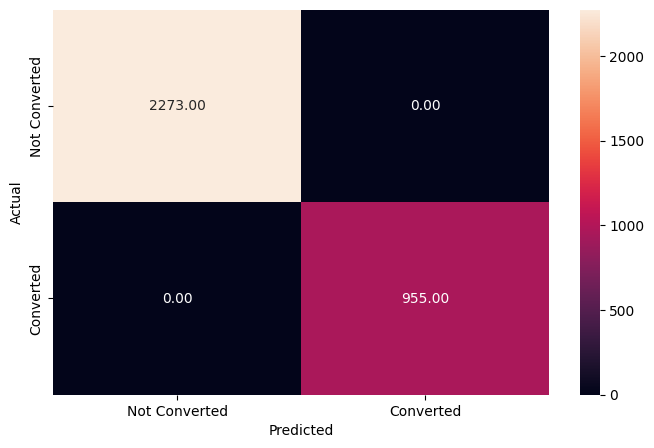

```
Decision Tree - Testing Set Performance:
              precision    recall  f1-score   support

           0       0.87      0.86      0.86       962
           1       0.69      0.70      0.70       422

    accuracy                           0.81      1384
   macro avg       0.78      0.78      0.78      1384
weighted avg       0.81      0.81      0.81      1384
```

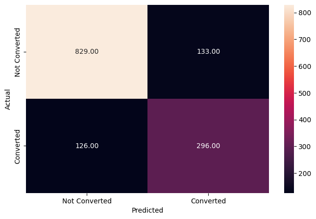

```python
# Check performance on training data
print("Decision Tree - Training Set Performance:")
y_predic_train1 = dtree.predict(X_train)
report(y_train, y_predic_train1)

# Check performance on testing data
print("Decision Tree - Testing Set Performance:")
y_predic_test1 = dtree.predict(X_test)
report(y_test, y_predic_test1)
```

## Do we need to prune the tree?

```python
# Choose the type of classifier
d_tree_tuned = DecisionTreeClassifier(random_state = 7, class_weight = {0: 0.3, 1: 0.7})

# Grid of parameters to choose from
parameters = {'max_depth': np.arange(2, 10),
              'criterion': ['gini', 'entropy'],
              'min_samples_leaf': [5, 10, 20, 25]
             }

# Type of scoring used to compare parameter combinations - recall score for class 1
scorer = metrics.make_scorer(recall_score, pos_label = 1)

# Run the grid search
grid_obj = GridSearchCV(d_tree_tuned, parameters, scoring = scorer, cv = 5)

grid_obj = grid_obj.fit(X_train, y_train)

# Set the classifier to the best combination of parameters
tuned_dtree = grid_obj.best_estimator_

# Fit the best algorithm to the data
tuned_dtree.fit(X_train, y_train)
```

```
DecisionTreeClassifier(class_weight={0: 0.3, 1: 0.7}, criterion='entropy',
                       max_depth=3, min_samples_leaf=5, random_state=7)
```

```
Pruned Decision Tree - Training Set Performance:
              precision    recall  f1-score   support

           0       0.94      0.77      0.85      2273
           1       0.62      0.88      0.73       955

    accuracy                           0.80      3228
   macro avg       0.78      0.83      0.79      3228
weighted avg       0.84      0.80      0.81      3228
```

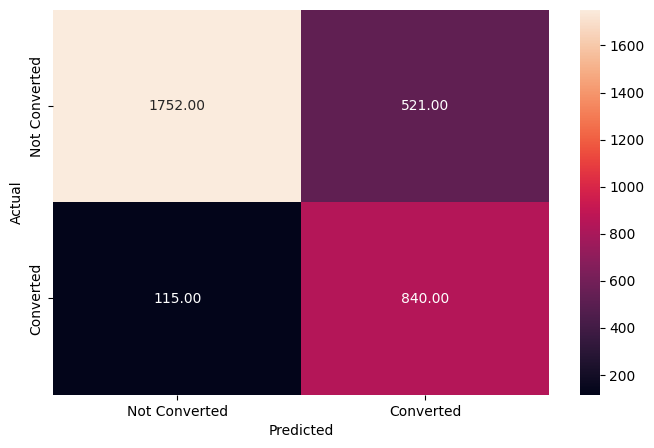

```
Pruned Decision Tree - Test Set Performance:
              precision    recall  f1-score   support

           0       0.93      0.77      0.84       962
           1       0.62      0.86      0.72       422

    accuracy                           0.80      1384
   macro avg       0.77      0.82      0.78      1384
weighted avg       0.83      0.80      0.80      1384
```

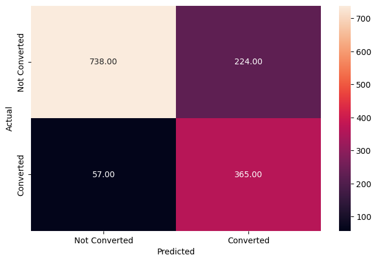

```python
y_train2 = tuned_dtree.predict(X_train)
y_test2 = tuned_dtree.predict(X_test)

print("Pruned Decision Tree - Training Set Performance:")
report(y_train, y_train2)

print("\nPruned Decision Tree - Test Set Performance:")
report(y_test, y_test2)
```

### Observation

**For Training set (post tuning)**

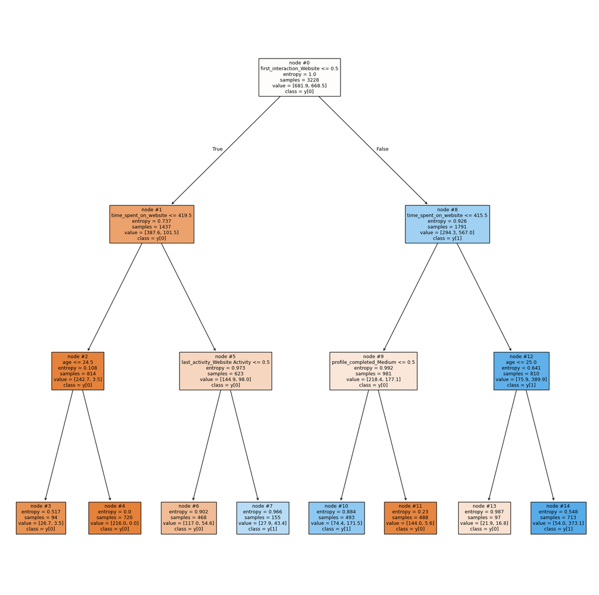

```python
#Visualize the decision tree after tuning
features = list(X.columns)

plt.figure(figsize = (20, 20))

plot_tree(tuned_dtree, feature_names = features, filled = True, fontsize = 9, node_ids = True, class_names = True)

plt.show()
```

### Observations

- The tuned version appears to have fewer levels and nodes. This suggests that hyperparameter tuning has successfully pruned the tree, potentially improving generalization and reducing overfitting.
- The tuned tree relies on a smaller subset of features.. This can lead to a more interpretable and efficient model.

```python
#Importance of features in the tree building
print(pd.DataFrame(tuned_dtree.feature_importances_, columns = ["Imp"], index = X_train.columns).sort_values(by = 'Imp', ascending = False))
```

```
                                     Imp
time_spent_on_website           0.348142
first_interaction_Website       0.327181
profile_completed_Medium        0.239274
age                             0.063893
last_activity_Website Activity  0.021511
website_visits                  0.000000
page_views_per_visit            0.000000
current_occupation_Student      0.000000
current_occupation_Unemployed   0.000000
profile_completed_Low           0.000000
last_activity_Phone Activity    0.000000
print_media_type1_Yes           0.000000
print_media_type2_Yes           0.000000
digital_media_Yes               0.000000
educational_channels_Yes        0.000000
referral_Yes                    0.000000
```

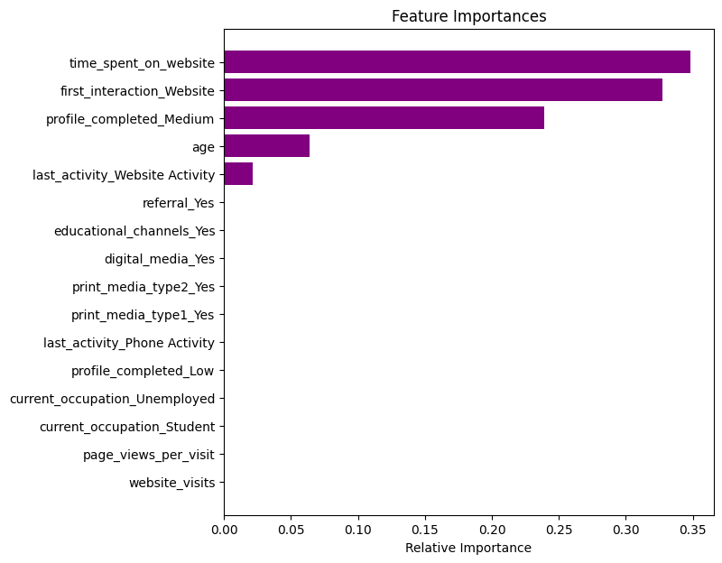

```python
# Plot the features importance
importance = tuned_dtree.feature_importances_

indices = np.argsort(importance)

plt.figure(figsize = (7, 7))
plt.title('Feature Importances')
plt.barh(range(len(indices)), importance[indices], color = 'purple', align= 'center')
plt.yticks(range(len(indices)), [features[i] for i in indices])
plt.xlabel('Relative Importance')
plt.show()
```

### **Observations**

- time_spent_on_website and first_interaction_website are the most important with relative importance 0.35 and around 0.33. Other features profile_completed_Medium, age, and last_activity have relative importance of 0.25, between 0.05-0.10, and less than 0.5.
- The rest of the Features have no importance at all.

## Building a Random Forest model

```python
# Fitting the random forest tree classifier on the training data
rf_estimator = RandomForestClassifier(random_state = 1)
rf_estimator.fit(X_train, y_train)
```

```
RandomForestClassifier(random_state=1)
```

```
Random Forest - Training Set Performance:
              precision    recall  f1-score   support

           0       1.00      1.00      1.00      2273
           1       1.00      1.00      1.00       955

    accuracy                           1.00      3228
   macro avg       1.00      1.00      1.00      3228
weighted avg       1.00      1.00      1.00      3228
```

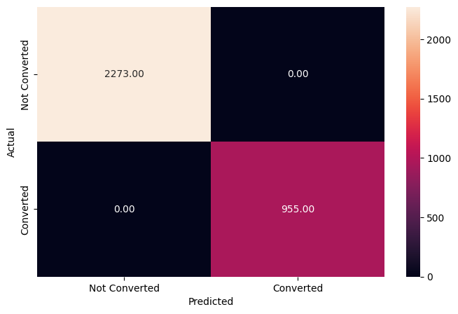

```
Random Forest - Test Set Performance:
              precision    recall  f1-score   support

           0       0.87      0.91      0.89       962
           1       0.78      0.68      0.73       422

    accuracy                           0.84      1384
   macro avg       0.82      0.80      0.81      1384
weighted avg       0.84      0.84      0.84      1384
```

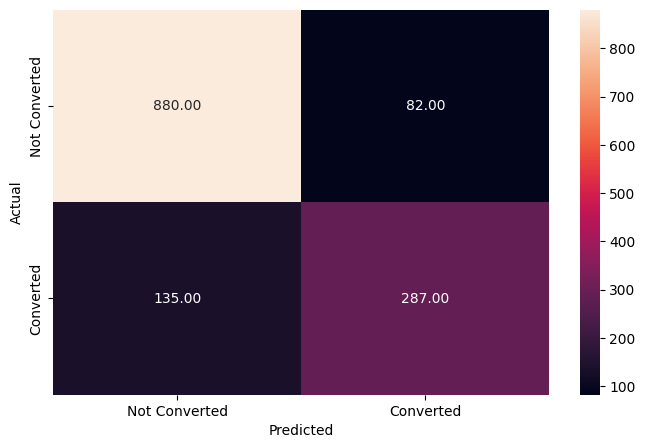

```python
# Check performance on training data
print("Random Forest - Training Set Performance:")
y_predic_train3 = rf_estimator.predict(X_train)
report(y_train, y_predic_train3)

# Checking performance on the training data
print("\nRandom Forest - Test Set Performance:")
y_predic_test3 = rf_estimator.predict(X_test)
report(y_test, y_predic_test3)
```

## Do we need to prune the tree?

```python
# Choose the type of classifier
tuned_rf = RandomForestClassifier(criterion = "entropy", random_state = 7)

# Grid of parameters to choose from
parameters = {"n_estimators": [110, 120],
    "max_depth": [6, 7],
    "min_samples_leaf": [20, 25],
    "max_features": [0.8, 0.9],
    "max_samples": [0.9, 1],
    "class_weight": ["balanced",{0: 0.3, 1: 0.7}]
             }

# Type of scoring used to compare parameter combinations - recall score for class 1
scorer = metrics.make_scorer(recall_score, pos_label = 1)

# Run the grid search on the training data using scorer=scorer and cv=5
grid_obj = GridSearchCV(estimator=tuned_rf, param_grid=parameters, scoring=scorer, cv=5)

grid_obj = grid_obj.fit(X_train, y_train)

# Save the best estimator to variable rf_estimator_tuned
tuned_rf = grid_obj.best_estimator_
```

```python
# Fit the best algorithm to the training data
tuned_rf.fit(X_train, y_train)
```

```
RandomForestClassifier(class_weight='balanced', criterion='entropy',
                       max_depth=6, max_features=0.8, max_samples=0.9,
                       min_samples_leaf=25, n_estimators=120, random_state=7)
```

```
Pruned Random Forest - Training Set Performance:
              precision    recall  f1-score   support

           0       0.83      0.94      0.88      1997
           1       0.87      0.68      0.76      1231

    accuracy                           0.84      3228
   macro avg       0.85      0.81      0.82      3228
weighted avg       0.84      0.84      0.83      3228
```

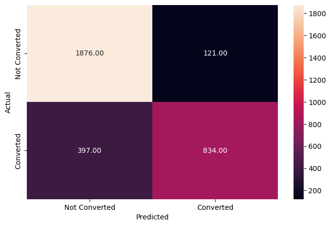

```
Pruned Random Forest - Test Set Performance:
              precision    recall  f1-score   support

           0       0.83      0.93      0.87       857
           1       0.85      0.68      0.76       527

    accuracy                           0.83      1384
   macro avg       0.84      0.81      0.82      1384
weighted avg       0.84      0.83      0.83      1384
```

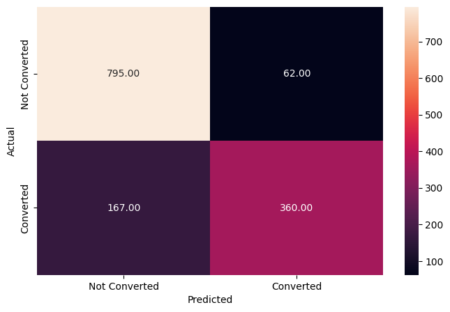

```python
# Check performance on training data
print("Pruned Random Forest - Training Set Performance:")
y_pred_train4 = tuned_rf.predict(X_train)
report(y_pred_train4, y_train)

# Check performance on test data
print("\nPruned Random Forest - Test Set Performance:")
y_pred_test4 = tuned_rf.predict(X_test)
report(y_pred_test4, y_test)
```

### Observation

**For Training set(post tuning)**

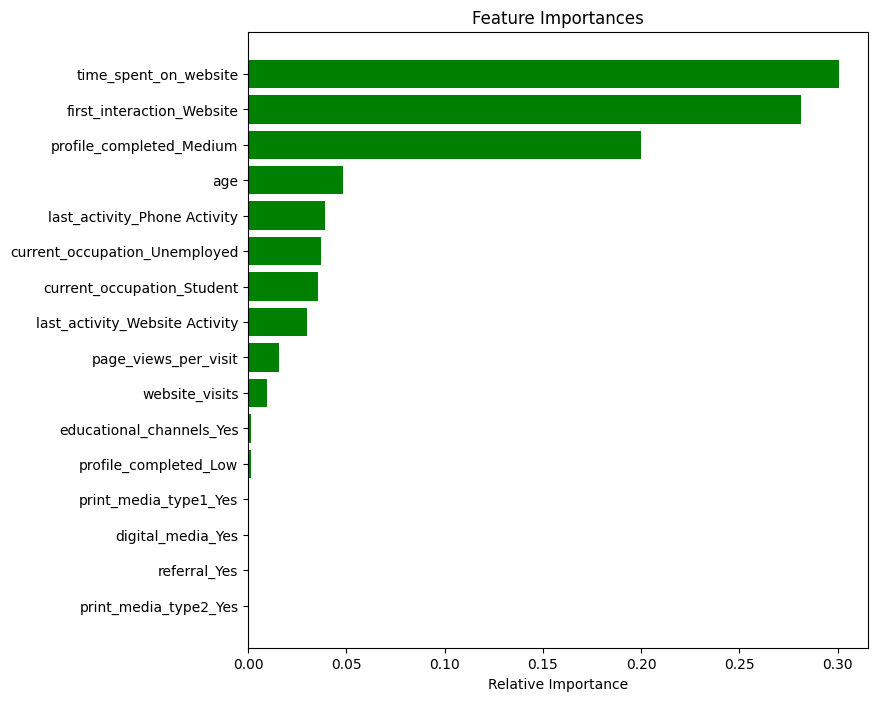

```python
importances = tuned_rf.feature_importances_

indices = np.argsort(importances)

feature_names = list(X.columns)

plt.figure(figsize = (8, 8))

plt.title('Feature Importances')

plt.barh(range(len(indices)), importances[indices], color = 'Green', align = 'center')

plt.yticks(range(len(indices)), [feature_names[i] for i in indices])

plt.xlabel('Relative Importance')

plt.show()
```

### Observation

- Time spent on the website and first interaction (Website) are the most influential features. This suggests that user engagement on the website is strongly correlated with the outcome.
- Profile completion (Medium) and age are also important factors, but to a lesser extent. This indicates that these factors might play a supporting role in the decision-making process.
- The majority of features have minimal or no impact on the model's predictions. This suggests that these features might not be strong discriminators of the target variable in this dataset.

## Actionable Insights and Recommendations

- Focus on website engagement:

Time spent on the website and first interaction via the website are the most important factors in predicting conversions. Recommendation: Optimize the website user experience to encourage longer visits and more page views. Consider adding interactive content, detailed program information, and easy navigation to keep users engaged.

- Improve mobile app conversion:

While the mobile app generates more leads, website interactions have a higher conversion rate. Recommendation: Analyze the mobile app user journey and identify potential friction points. Enhance the app's features to match the website's effectiveness in converting leads.

- Target older demographics:

There's a weak positive correlation between age and conversion, with a higher concentration of leads in older age ranges. Recommendation: Tailor marketing messages and program offerings to appeal to older professionals and those nearing retirement age, as they seem more likely to convert.

- Optimize for unemployed leads:

Unemployed individuals have the highest proportion of conversions among occupational groups. Recommendation: Create targeted campaigns and programs specifically for job seekers or career changers, emphasizing how ExtraaLearn can help with reskilling and finding new opportunities.

- Encourage profile completion:

Leads with high profile completion have a significantly higher conversion rate (42%) compared to low completion (7%). Recommendation: Implement a gamified system or offer incentives for users to complete their profiles. Send reminders and highlight the benefits of having a complete profile.

- Leverage email marketing:

Email activity is the most frequent last activity and has the highest number of conversions. Recommendation: Invest in a robust email marketing strategy. Segment your email list based on user behavior and preferences to send targeted, personalized content that encourages conversion.

- Expand referral program:

While referrals are rare (only 2% of leads), they have a dramatically higher conversion rate. Recommendation: Develop a strong referral program with incentives for both the referrer and the new lead. Actively encourage satisfied customers to refer others.

- Reassess advertising channels:

Print media, digital media, and educational channels show higher conversion rates for exposed leads, despite reaching a small audience. Recommendation: Conduct a cost-benefit analysis of these channels. If cost-effective, consider increasing investment in these targeted advertising methods to reach high-quality leads.

- Implement lead scoring:

Use the insights from the machine learning models to develop a lead scoring system. Recommendation: Assign scores to leads based on factors like website engagement, profile completion, and demographic information. Prioritize high-scoring leads for sales follow-ups.

- Personalize the user journey:
- Different groups (e.g., by occupation, age) show varying conversion patterns. Recommendation: Implement personalized user journeys based on initial user data. For example, tailor content and programs shown to users based on their occupation and age group.
- Optimize resource allocation:

The overall conversion rate is relatively low at about 30%. Recommendation: Use the predictive models to identify high-potential leads and allocate more resources to nurturing these leads. This could improve overall conversion efficiency.

- Continuous monitoring and refinement:

The machine learning models, particularly Random Forest, show good predictive power. Recommendation: Regularly update and refine these models with new data. Use the models' insights to continuously adjust marketing strategies and lead nurturing processes.